# Chapter 3: Data Visualisation

### 3.6.6

> Recreate the R code necessary to generate the following graphs.

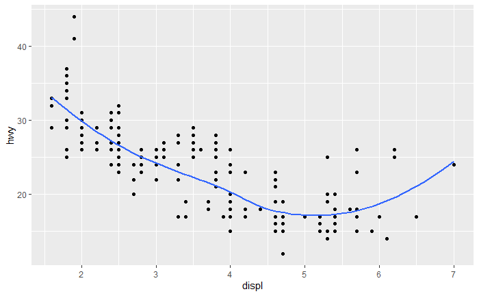

```r
ggplot(mpg, aes(displ, hwy)) +
  geom_point() +
  geom_smooth(se = FALSE)
```

[figure not shown]

```r
ggplot(mpg, aes(displ, hwy, line = drv)) +
  geom_point() +
  geom_smooth(se = FALSE)
```

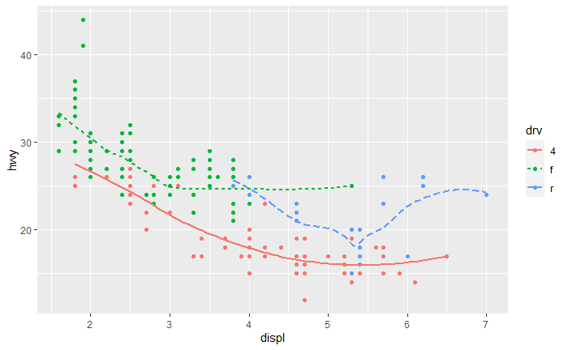

```r
ggplot(mpg, aes(displ, hwy, colour = drv)) +
  geom_point() +
  geom_smooth(se = FALSE)
ggplot(mpg, aes(displ, hwy, colour = drv)) +
  geom_point() +
  geom_smooth(se = FALSE)
ggplot(mpg, aes(displ, hwy, colour = drv, colour = drv, linetype = drv)) +
  geom_point() +
  geom_smooth(se = FALSE)
```

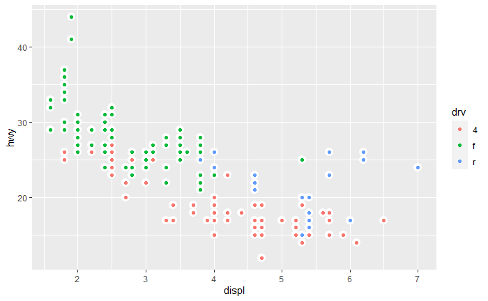

```r
ggplot(mpg, aes(displ, hwy, colour = drv)) +
  geom_point(size = 4, colour = "white") +
  geom_point(aes(colour = drv))
```

```r
NA
```

## 3.7 Statistical Transformations

### 3.7.1

> What is the default geom associated with `stat_summary()`? How could you rewrite the following plot to use that geom function instead of the stat function?

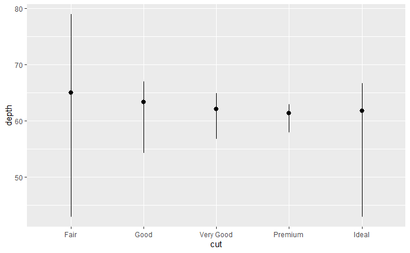

```r
ggplot(data = diamonds) +
  stat_summary(
    mapping = aes(x = cut, y = depth),
    fun.min = min,
    fun.max = max,
    fun = median
  )
```

Default geom for `stat_summary()` is `geom_pointrange`, but the default stat for `geom_pointrange` is ‘identity’.

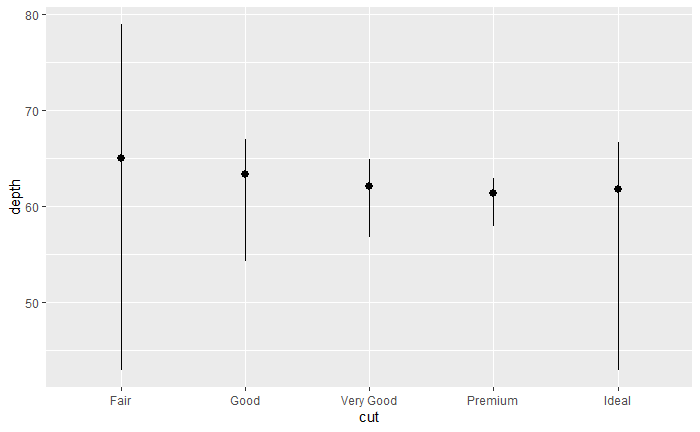

```r
ggplot(data = diamonds) +
  geom_pointrange(
    mapping = aes(x = cut, y = depth),
    stat = 'summary',
    fun.max = max,
    fun.min = min,
    fun = median
  )
```

```r
NA
```

### 3.7.2

> What does `geom_col()` do? How is it different to `geom_bar()`? `geom_col()` by default uses `stat_identity()`, leaves the data as is and expects both `x` and `y` mappings. `geom_bar` by default uses `stat_count`, only expects an `x` mapping and calculates the number of observations for each value of x.

### 3.7.3

> Most geoms and stats come in pairs that are almost always used in concert. Read through the documentation and make a list of all the pairs. What do they have in common?

Complementary geoms and stats.

| geom | stat |
| --- | --- |
| `geom_bar()` | `stat_count()` |
| `geom_bin2d()` | `stat_bin_2d()` |
| `geom_boxplot()` | `stat_boxplot()` |
| `geom_contour_filled()` | `stat_contour_filled()` |
| `geom_contour()` | `stat_contour()` |
| `geom_count()` | `stat_sum()` |
| `geom_density_2d()` | `stat_density_2d()` |
| `geom_density()` | `stat_density()` |
| `geom_dotplot()` | `stat_bindot()` |
| `geom_function()` | `stat_function()` |
| `geom_sf()` | `stat_sf()` |
| `geom_sf()` | `stat_sf()` |
| `geom_smooth()` | `stat_smooth()` |
| `geom_violin()` | `stat_ydensity()` |
| `geom_hex()` | `stat_bin_hex()` |
| `geom_qq_line()` | `stat_qq_line()` |
| `geom_qq()` | `stat_qq()` |
| `geom_quantile()` | `stat_quantile()` |

ggplot2 geom layers and their default stats.

| geom | default stat | shared docs |
| --- | --- | --- |
| `geom_abline()` | `stat_identity()` |  |
| `geom_area()` | `stat_identity()` |  |
| `geom_bar()` | `stat_count()` | x |
| `geom_bin2d()` | `stat_bin_2d()` | x |
| `geom_blank()` | None |  |
| `geom_boxplot()` | `stat_boxplot()` | x |
| `geom_col()` | `stat_identity()` |  |
| `geom_count()` | `stat_sum()` | x |
| `geom_countour_filled()` | `stat_countour_filled()` | x |
| `geom_countour()` | `stat_countour()` | x |
| `geom_crossbar()` | `stat_identity()` |  |
| `geom_curve()` | `stat_identity()` |  |
| `geom_density_2d_filled()` | `stat_density_2d_filled()` | x |
| `geom_density_2d()` | `stat_density_2d()` | x |
| `geom_density()` | `stat_density()` | x |
| `geom_dotplot()` | `stat_bindot()` | x |
| `geom_errorbar()` | `stat_identity()` |  |
| `geom_errorbarh()` | `stat_identity()` |  |
| `geom_freqpoly()` | `stat_bin()` | x |
| `geom_function()` | `stat_function()` | x |
| `geom_hex()` | `stat_bin_hex()` | x |
| `geom_histogram()` | `stat_bin()` | x |
| `geom_hline()` | `stat_identity()` |  |
| `geom_jitter()` | `stat_identity()` |  |
| `geom_label()` | `stat_identity()` |  |
| `geom_line()` | `stat_identity()` |  |
| `geom_linerange()` | `stat_identity()` |  |
| `geom_map()` | `stat_identity()` |  |
| `geom_path()` | `stat_identity()` |  |
| `geom_point()` | `stat_identity()` |  |
| `geom_pointrange()` | `stat_identity()` |  |
| `geom_polygon()` | `stat_identity()` |  |
| `geom_qq_line()` | `stat_qq_line()` | x |
| `geom_qq()` | `stat_qq()` | x |
| `geom_quantile()` | `stat_quantile()` | x |
| `geom_raster()` | `stat_identity()` |  |
| `geom_rect()` | `stat_identity()` |  |
| `geom_ribbon()` | `stat_identity()` |  |
| `geom_rug()` | `stat_identity()` |  |
| `geom_segment()` | `stat_identity()` |  |
| `geom_sf_label()` | `stat_sf_coordinates()` | x |
| `geom_sf_text()` | `stat_sf_coordinates()` | x |
| `geom_sf()` | `stat_sf()` | x |
| `geom_smooth()` | `stat_smooth()` | x |
| `geom_spoke()` | `stat_identity()` |  |
| `geom_step()` | `stat_identity()` |  |
| `geom_text()` | `stat_identity()` |  |
| `geom_tile()` | `stat_identity()` |  |
| `geom_violin()` | `stat_ydensity()` | x |
| `geom_vline()` | `stat_identity()` |  |

ggplot2 stat layers and their default geoms.

| stat | default geom | shared docs |
| --- | --- | --- |
| `stat_bin_2d()` | `geom_tile()` |  |
| `stat_bin_hex()` | `geom_hex()` | x |
| `stat_bin()` | `geom_bar()` | x |
| `stat_boxplot()` | `geom_boxplot()` | x |
| `stat_count()` | `geom_bar()` | x |
| `stat_countour_filled()` | `geom_contour_filled()` | x |
| `stat_countour()` | `geom_contour()` | x |
| `stat_density_2d_filled()` | `geom_density_2d()` | x |
| `stat_density_2d()` | `geom_density_2d()` | x |
| `stat_density()` | `geom_area()` |  |
| `stat_ecdf()` | `geom_step()` |  |
| `stat_ellipse()` | `geom_path()` |  |
| `stat_function()` | `geom_function()` | x |
| `stat_function()` | `geom_path()` |  |
| `stat_identity()` | `geom_point()` |  |
| `stat_qq_line()` | `geom_path()` |  |
| `stat_qq()` | `geom_point()` |  |
| `stat_quantile()` | `geom_quantile()` | x |
| `stat_sf_coordinates()` | `geom_point()` |  |
| `stat_sf()` | `geom_rect()` |  |
| `stat_smooth()` | `geom_smooth()` | x |
| `stat_sum()` | `geom_point()` |  |
| `stat_summary_2d()` | `geom_tile()` |  |
| `stat_summary_bin()` | `geom_pointrange()` |  |
| `stat_summary_hex()` | `geom_hex()` |  |
| `stat_summary()` | `geom_pointrange()` |  |
| `stat_unique()` | `geom_point()` |  |
| `stat_ydensity()` | `geom_violin()` | x |

### 3.7.4

> What variables does `stat_smooth()` compute? What parameters control its behaviour?

```r
?stat_smooth
```

`geom_smooth` and `stat_smooth` are aliases and use the same arguments. These methods/arguments are: - `method`: smoothing method. e.g. `NULL`, `lm`, `glm`, `loess`. - `formula`: customiing smoothing method - `se`: If `TRUE`, displays standard error bands. - `na.rm`: missing values are removed with `FALSE` or without `TRUE` error messages.

Computed variables of `stat_smooth` include: - `y`: predicted values - `ymin`: lower value of the confidence interval - `ymax`: upper value of confidence interval - `se`: standard error

### 3.7.5

> In our proportion bar chart, we need to set group = 1. Why? In other words what is the problem with these two graphs?

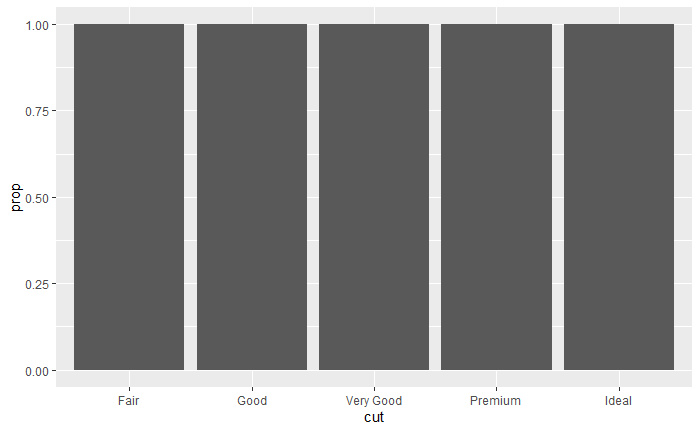

```r
ggplot(data = diamonds) +
  geom_bar(mapping = aes(x = cut, y = after_stat(prop)))
```

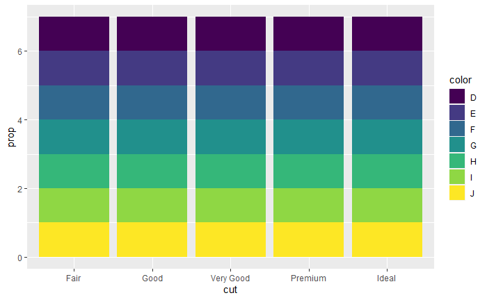

```r
ggplot(data = diamonds) +
  geom_bar(mapping = aes(x = cut, fill = color, y = after_stat(prop)))
```

From `?geom_bar`: `geom_bar()` makes the height of the bar proportional to the number of cases in each group. Proportions are calculated within each group so they all have the same height. The correct plot is:

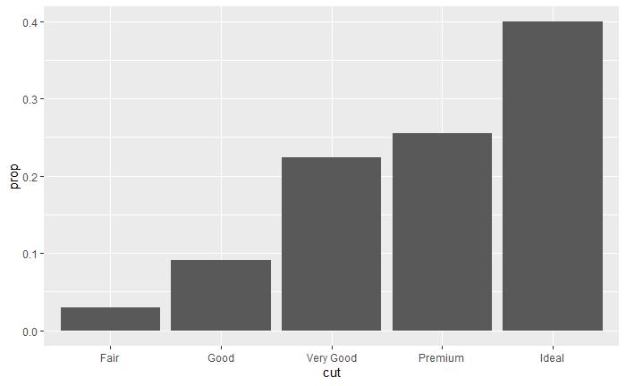

```r
ggplot(data = diamonds) +
  geom_bar(mapping = aes(x = cut, y = stat(prop), group = 1))
```

## 3.8 Position adjustments

### 3.8.1

> What is the problem with this plot? How could you improve it?

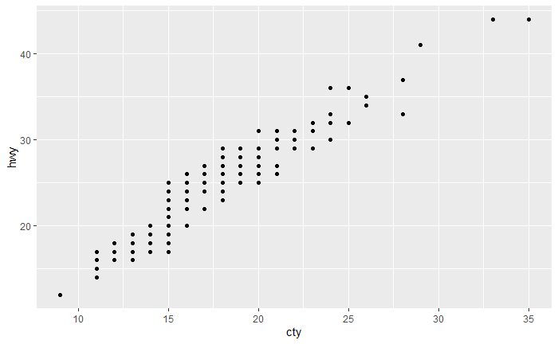

```r
ggplot(data = mpg, mapping = aes(x = cty, y = hwy)) +
  geom_point()
```

There are missing observations in this plot because they are stacked. We can apply a jitter (random noise displacement) to each observation so they are less likely to stack. This reduces accuracy. Use `geom_jitter` or add a `position = "jitter"` argument to `geom_point`.

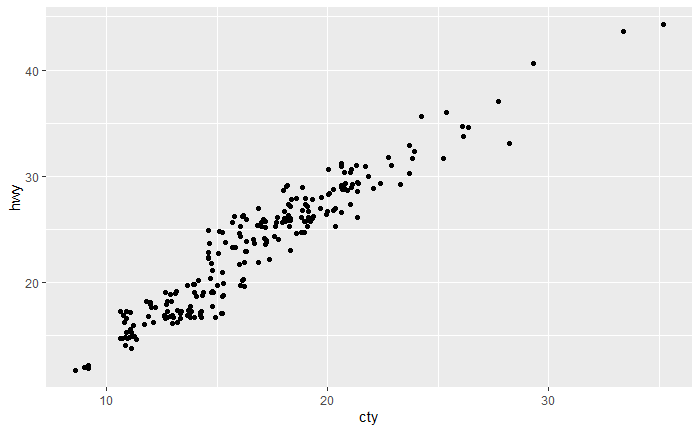

```r
ggplot(data = mpg, mapping = aes(x = cty, y = hwy)) +
  geom_point(position = "jitter" )
```